# **R Code sample part 5**

Ivan Baksic

## 5) Additional plots

In this part I displayed additional result plots.  
I plotted Spearman’s rank correlation coefficient between mutation and chromatin marks for every biosample individually.  
I also plotted melanoma SNP mutation window count vs chromatin marks peak count and compared their Spearman’s rank correlation coefficient for the top biosample.  
Finally, I plotted observed vs predicted values for the top biosample model.

Packages used

```r
library(dplyr)
library(tidyr)
library(ggplot2)
library(forcats)
library(ggtext)
```

I loaded mark and mutation count data used in model building and Random Forest regression results for all 104 biosamples.

```r
SKCA_BR_full_WGS_SNP_table_no_out <- readRDS(url("https://github.com/Baksic-Ivan/R_code_sample-Cancer_Cell-of-Origin_Determination/raw/main/SKCA_BR_full_WGS_SNP_table_no_out.RDS"))

SKCA_BR_full_WGS_SNP_table_no_out_104model <- readRDS(url("https://github.com/Baksic-Ivan/R_code_sample-Cancer_Cell-of-Origin_Determination/raw/main/SKCA_BR_full_WGS_SNP_table_no_out_104model.RDS"))
```

Spearman’s rank correlation coefficient between mutation and chromatin marks for every biosample.

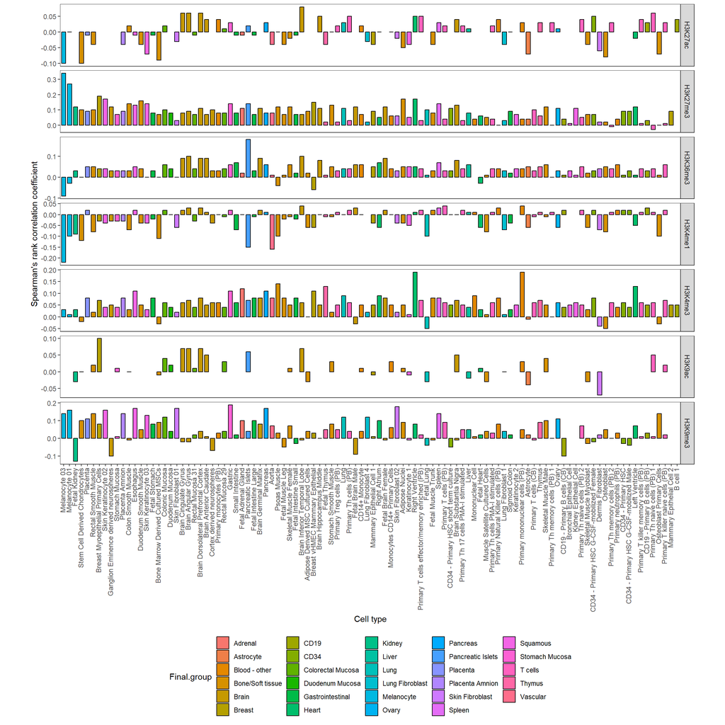

```r
plot_sm_corelations <- function (Rsquared_result, input_table) {

  # create a table of spearman correlations
  cor_table <- sapply(input_table, function (x){

    # apply function on mark columns
    cor_results <- sapply(1:(ncol(x) - 1), function(y){

      # select mutation column
      last <- x[, ncol(x)] %>% unlist(.)

      # select mark column
      mark <- x[, y] %>% unlist(.)

      # determine spearman correlation
      result <- cor(mark, last, method = "spearman")
      names(result) <- colnames(x)[y]
      return(result)
      }) %>% round(., 2)
  }) %>%
    bind_rows(., .id = "biosample")

  # get marker names
  marker_names <- colnames(cor_table)[-1]

  # extract data frame of R2 results for every biosample and
  Rsquared_result_table <- Rsquared_result[1, ] %>% unlist(.) %>%
    data.frame(Rsquared = ., biosample = names(.)) %>%
    mutate(., Rsquared = Rsquared*100) %>%
    # arrange it in descending order
    arrange(., desc(Rsquared))

  my_samples <- read.csv("https://raw.githubusercontent.com/Baksic-Ivan/R_code_sample-Cancer_Cell-of-Origin_Determination/main/biomarker_list.csv")

  Rsquared_result_gg <- my_samples %>% mutate(., biosample = Final.name) %>%
    #add group names to result data frame from biomarker data frame based on biosample column
    left_join(Rsquared_result_table, ., by = "biosample") %>%
    #add spearman correlation columns based on biosample column
    left_join(., cor_table, by = "biosample")

  plot <- Rsquared_result_gg %>%
    # map biosamples to descending order of Rsquared column
    mutate(biosample = forcats::fct_reorder(biosample, dplyr::desc(Rsquared))) %>%

    # transpose data frame
    pivot_longer(., cols = marker_names, names_to = "marker", values_to = "spearman") %>%

    # CREATE PLOT
    # fill biosample bars by their group
    ggplot(aes(x = biosample, y = spearman, fill = Final.group)) +

    # create bar plot
    geom_col(width = 0.7, color = "black") +
    #scale_y_continuous(expand = c(0,0)) +

    # set theme
    theme_bw() +

    # form matrix of panels by marker column
    facet_grid(vars(marker), scales = "free") +

    # set biosample names vertical
    theme(axis.text.x = element_text(angle = 90, vjust = 0.3, hjust = 1, size = 9), aspect.ratio = 1/10,
          panel.grid.major = element_line(colour = "white"),
          panel.grid.minor = element_line(colour = "white"),
          legend.position="bottom") +

    # label axis
    xlab("Cell type") +
    ylab("Spearman's rank correlation coefficient")


  return(plot)
}

plot_sm_corelations(SKCA_BR_full_WGS_SNP_table_no_out_104model, SKCA_BR_full_WGS_SNP_table_no_out)
```

I observed that SNP mutation in Melanoma group positively correlates with H3K27me3, H3K4me3 and H3K9me3, chromatin marks responsible for decrease in DNA access and negatively correlates with H3K27ac, H3K36me3 and H3K4me1, chromatin marks responsible for increased in DNA access. This means that in melanoma SNP mutations are more likely to accumulate closed chromatin regions.

To visualise this correlation, I plotted melanoma SNP mutation window count vs chromatin marks peak count for the top biosample (Melanocyte 03).

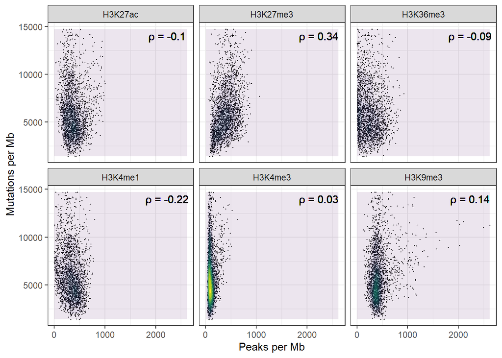

```r
mark_VS_mutation_plots <- function(input_table){

  # transpose input data frame into longer format
  mark_table <- rename(input_table,
                       tumor_count_per_1Mb_window = mutation) %>%
    pivot_longer(.,
                 cols = -tumor_count_per_1Mb_window,
                 names_to = "chromatin_mark",
                 values_to = "mark_count_per_1Mb_window")

  # apply function on mark columns
  spearman_score <- sapply(1:(ncol(input_table) - 1), function(x){
    # select mutation column
    last <- input_table[, ncol(input_table)] %>% unlist(.)
    # select mark column
    mark <- input_table[, x] %>% unlist(.)
    # determine spearman correlation
    result <- cor(mark, last, method = "spearman")
    return(result)
    }) %>% round(., 2)

  # assign markers to their scores
  spearman_names <- setdiff(names(input_table), "mutation")
  spearman_df <- data.frame(score = paste("ρ = ", spearman_score, sep = ""),
                          chromatin_mark = spearman_names)

  f_table <- inner_join(mark_table, spearman_df, by = "chromatin_mark")

  # create mark count vs tumor count plot
  ggplot(f_table, aes(x = mark_count_per_1Mb_window, y = tumor_count_per_1Mb_window)) +
    geom_point(size = 0.2) +
    theme_bw() +

    # add spearman score
    geom_text(mapping = aes(x = max(mark_count_per_1Mb_window) * 0.85,
                            y = max(tumor_count_per_1Mb_window) * 0.95,
                            label = score)) +

    # mark dot density by color
    geom_density_2d_filled(aes(alpha = after_stat(as.factor(..level..))), contour_var = "count", show.legend = F) +

    # form matrix of panels by marker column
    facet_wrap(vars(chromatin_mark)) +

     #label axis
    xlab("Peaks per Mb") +
    ylab("Mutations per Mb")
}

mark_VS_mutation_plots(SKCA_BR_full_WGS_SNP_table_no_out$`Melanocyte 03`)
```

At the end, I plotted observed versus predicted mutation values for the best model (Melanocyte 03).

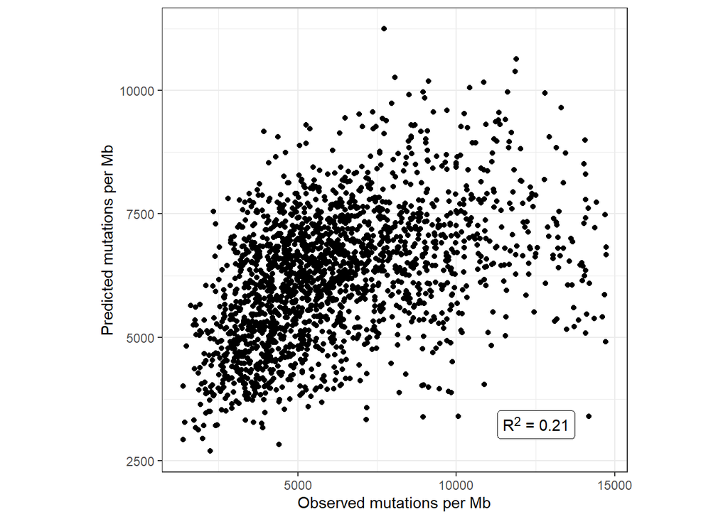

```r
plot_best_obs_pred <- function (Rsquared_result) {

  # get biosample with highest Rsquared
  max_biosample <- Rsquared_result[1,] %>%
    unlist(.) %>%
    which.max(.) %>%
    names(.)

  # CREATE PLOT
  plot <- Rsquared_result[2, max_biosample][[1]] %>%

    # point plot of observed vs predicted values
    ggplot(., aes(x = obs, y = pred)) +
    geom_point() +

    # theme and plot ratio selection
    theme_bw() +
    theme(aspect.ratio = 1/1) +

    #name lables
    xlab("Observed mutations per Mb") +
    ylab("Predicted mutations per Mb") +

    # add Rsquared value on the plot
    geom_richtext(mapping = aes(x = max(obs) * 0.85,
                            y = min(pred) * 1.2,
                            label = paste("R<sup>2</sup> = ", round(Rsquared_result[[1, max_biosample]], 2), sep = "")))
  return(plot)
}

plot_best_obs_pred(SKCA_BR_full_WGS_SNP_table_no_out_104model)
```